# Kapcsolatszorossági módszerek áttekintése

Van-e összefüggés az apa és anya iskolai végzettsége között? Ha igen, milyen jellegű (irány, erősség). A kérdést különbözőképpen is megfogalmazzuk és több statisztikai módszerrel vizsgáljuk. Az adatok a [GSS](https://gss.norc.org/)-ből származnak.

## Minőségi ismérvek között (nominális szint)

Két minőségi ismérv közötti kétváltozós kapcsolatvizsgálati módszerrel vizsgálható: **asszocsiáció**. Kereszttáblás elemzéssel végezzük, a kapcsolatszorossági mutató **C**.

### Hipotézisek:

**H0:** apák és anyák végzettsége között nincs kapcsolat (függetlenség)

**H1:** apák és anyák végzettsége között van kapcsolat

### Előfeltétel:

$f* \ge 5$

```r
table (df$padeg)
```

```
#>
#>    1    2    3    4    5
#>  663 1010   64  273  159
```

```r
table (df$degree)
```

```
#>
#> Lt High School    High School Junior College       Bachelor       Graduate
#>            328           1461            216            536            318
```

```r
chi_teszt <- chisq.test (df$padeg , df$madeg)

# megfigyelés/valóság
chi_teszt$observed
```

```
#>         df$madeg
#> df$padeg   1   2   3   4   5
#>        1 420 173  11   9   6
#>        2 102 685  58  77  26
#>        3   6  30   7  14   4
#>        4  12 113  14  89  29
#>        5   2  40   7  52  56
```

```r
# f* függetlenség esetén elvárt
chi_teszt$expected
```

```
#>         df$madeg
#> df$padeg         1         2         3          4         5
#>        1 164.29873 315.56268 29.404016  73.055338 36.679236
#>        2 251.62390 483.28501 45.032321 111.884427 56.174339
#>        3  16.19099  31.09745  2.897649   7.199314  3.614594
#>        4  68.21450 131.01714 12.208129  30.331538 15.228697
#>        5  41.67189  80.03771  7.457884  18.529383  9.303134
```

Az előfeltétel két esetben sérül, ugyanakkor 25 esetből elhanyagolható hozzájárulással bír, úgyhogy ettől eltekinthetünk.

### Teszt eredménye:

```r
chi_teszt
```

```
#>
#>  Pearson's Chi-squared test
#>
#> data:  df$padeg and df$madeg
#> X-squared = 1306.1, df = 16, p-value < 2.2e-16
```

```r
chi_teszt2 <- gmodels::CrossTable (df$padeg , df$madeg,
                     prop.c = F, prop.r = T, prop.t = F,
                     digits = 2, prop.chisq = T,
                     chisq = T)
```

```
#>
#>
#>    Cell Contents
#> |-------------------------|
#> |                       N |
#> | Chi-square contribution |
#> |           N / Row Total |
#> |-------------------------|
#>
#>
#> Total Observations in Table:  2042
#>
#>
#>              | df$madeg
#>     df$padeg |         1 |         2 |         3 |         4 |         5 | Row Total |
#> -------------|-----------|-----------|-----------|-----------|-----------|-----------|
#>            1 |       420 |       173 |        11 |         9 |         6 |       619 |
#>              |    397.95 |     64.41 |     11.52 |     56.16 |     25.66 |           |
#>              |      0.68 |      0.28 |      0.02 |      0.01 |      0.01 |      0.30 |
#> -------------|-----------|-----------|-----------|-----------|-----------|-----------|
#>            2 |       102 |       685 |        58 |        77 |        26 |       948 |
#>              |     88.97 |     84.19 |      3.73 |     10.88 |     16.21 |           |
#>              |      0.11 |      0.72 |      0.06 |      0.08 |      0.03 |      0.46 |
#> -------------|-----------|-----------|-----------|-----------|-----------|-----------|
#>            3 |         6 |        30 |         7 |        14 |         4 |        61 |
#>              |      6.41 |      0.04 |      5.81 |      6.42 |      0.04 |           |
#>              |      0.10 |      0.49 |      0.11 |      0.23 |      0.07 |      0.03 |
#> -------------|-----------|-----------|-----------|-----------|-----------|-----------|
#>            4 |        12 |       113 |        14 |        89 |        29 |       257 |
#>              |     46.33 |      2.48 |      0.26 |    113.48 |     12.45 |           |
#>              |      0.05 |      0.44 |      0.05 |      0.35 |      0.11 |      0.13 |
#> -------------|-----------|-----------|-----------|-----------|-----------|-----------|
#>            5 |         2 |        40 |         7 |        52 |        56 |       157 |
#>              |     37.77 |     20.03 |      0.03 |     60.46 |    234.39 |           |
#>              |      0.01 |      0.25 |      0.04 |      0.33 |      0.36 |      0.08 |
#> -------------|-----------|-----------|-----------|-----------|-----------|-----------|
#> Column Total |       542 |      1041 |        97 |       241 |       121 |      2042 |
#> -------------|-----------|-----------|-----------|-----------|-----------|-----------|
#>
#>
#> Statistics for All Table Factors
#>
#>
#> Pearson's Chi-squared test
#> ------------------------------------------------------------
#> Chi^2 =  1306.088     d.f. =  16     p =  2.474005e-268
#>
#>
#>
```

```r
(C <- sqrt (1306.1/4/2042))
```

```
#> [1] 0.3998806
```

Tehát szignifikáns kapcsolatot mutathatunk ki, amely közepes erősségű.

### Vizuálisan:

*Ábrák:*

[output not shown]

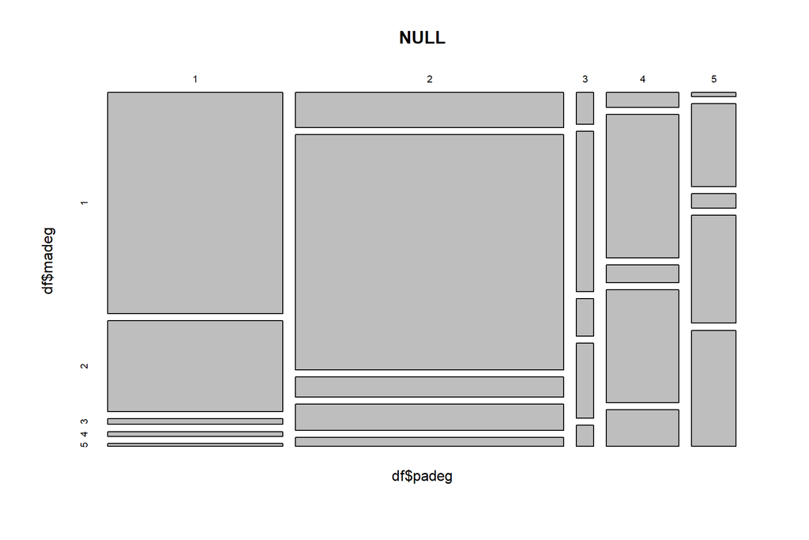

Szülők iskolai végzettségének együttes előfordulásai

```r
# mozaik
mosaicplot (df$padeg ~ df$madeg)
```

[output not shown]

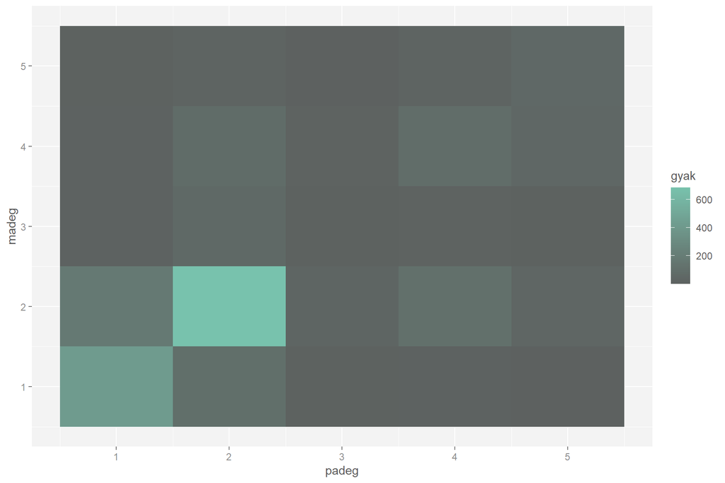

Szülők iskolai végzettségének együttes előfordulásai

```r
# csempe - gyakoriság szerinti színezés
df %>%
  group_by (padeg , madeg) %>%
  summarise( gyak = n()) %>%

ggplot ( aes (x = padeg , y = madeg , fill = gyak)) +
  geom_tile ()
```

[output not shown]

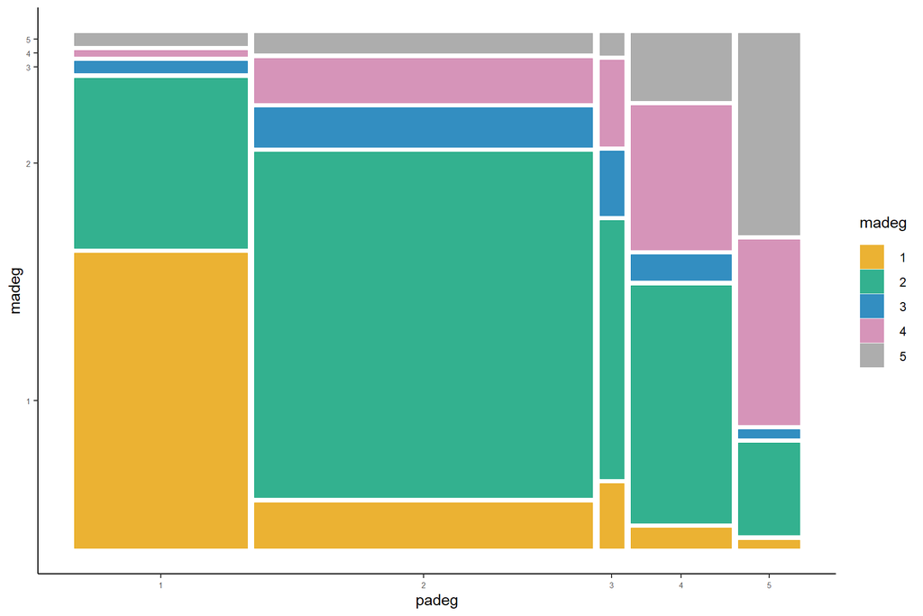

Szülők iskolai végzettségének együttes előfordulásai

```r
library (ggmosaic)

na.omit (df) %>%
  mutate (padeg = factor (padeg),
          madeg = factor (madeg)) %>%
  group_by (padeg , madeg) %>%
  summarise( gyak = n()) %>%
ggplot ( ) +
  geom_mosaic ( aes (weight = gyak,
                     x = product (padeg) ,
                     fill = madeg)) +
  theme_classic ()
```

Ha szeretnénk tudni, honnan származik a legnagyobb eltérés:

```r
chi_teszt$stdres
```

```
#>         df$madeg
#> df$padeg           1           2           3           4           5
#>        1  27.8819696 -13.7309091  -4.1658416  -9.5592932  -6.2563928
#>        2 -15.0357975  17.9046789   2.7051251  -4.7977431  -5.6709024
#>        3  -3.0001814  -0.2853778   2.5070533   2.7400833   0.2121969
#>        4  -8.4937795  -2.4045919   0.5620293  12.1321358   3.8914960
#>        5  -7.4630392  -6.6528068  -0.1788086   8.6174038  16.4289372
```

[output not shown]

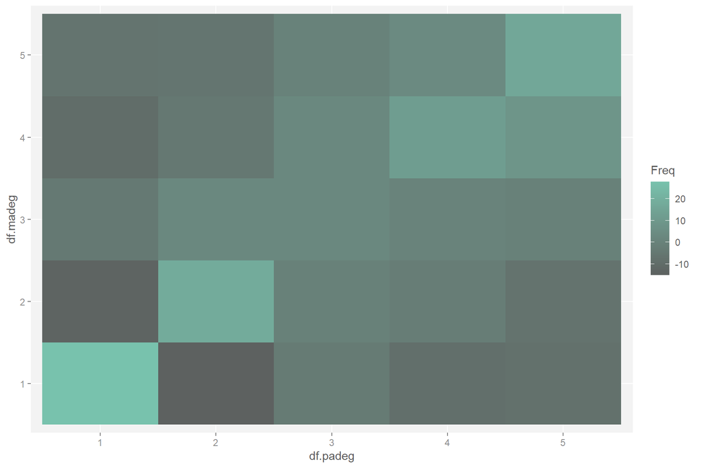

A függetlenséghez képesti eltérések nagysága iskolaivégzettség-páronként

```r
as.data.frame (chi_teszt$stdres) %>%
  ggplot ( aes (df.padeg , df.madeg , fill = Freq)) +
  geom_tile ()
```

## Sorbarendezhető minőségi (ordinális szint)

Rangkorrelációt használhatunk, mivel a végzettség sorbarendezhető, ordinális skálán mér. A sok kapcsolt rang miatt mégkorrektebb a Kendall-féle rangkorreláció.

### Hipotézisek:

$$H0: \rho = 0$$
$$H1: \rho \ne 0$$

### Teszt eredménye:

```r
cor.test (df$padeg , df$madeg , use = "pairwise.complete" ,
     method = "spearman")
```

```
#>
#>  Spearman's rank correlation rho
#>
#> data:  df$padeg and df$madeg
#> S = 516822460, p-value < 2.2e-16
#> alternative hypothesis: true rho is not equal to 0
#> sample estimates:
#>       rho
#> 0.6358121
```

```r
cor (df$padeg , df$madeg , use = "pairwise.complete" ,
     method = "kendall")
```

```
#> [1] 0.5795948
```

[output not shown]

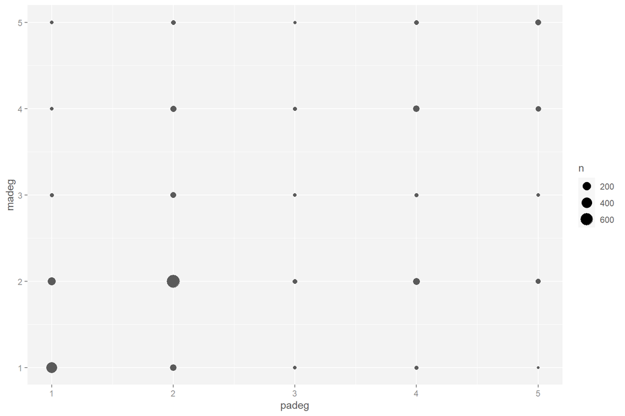

```r
ggplot (df , aes (x = padeg , y = madeg)) +
  geom_count ()
```

Szignifikáns pozitív erős együttjárás figyelhető meg a szülőpárok végzettsége között.

## Két csoport között van különbség?

Ezt a mérési szinttől függően különböző módszerekkel vizsgálhatjuk.

### Páros mintás t próba (intervallum szint)

```r
t.test (df$padeg , df$madeg , paired = T)
```

```
#>
#>  Paired t-test
#>
#> data:  df$padeg and df$madeg
#> t = 0.56848, df = 2041, p-value = 0.5698
#> alternative hypothesis: true difference in means is not equal to 0
#> 95 percent confidence interval:
#>  -0.03239136  0.05883602
#> sample estimates:
#> mean of the differences
#>              0.01322233
```

```r
# ugyanaz mint a különbségekre futtatott 1-mintás t próba
t.test (df$padeg - df$madeg)
```

```
#>
#>  One Sample t-test
#>
#> data:  df$padeg - df$madeg
#> t = 0.56848, df = 2041, p-value = 0.5698
#> alternative hypothesis: true mean is not equal to 0
#> 95 percent confidence interval:
#>  -0.03239136  0.05883602
#> sample estimates:
#>  mean of x
#> 0.01322233
```

Nem szignifikáns a teszt, tehát nincs kimutatható különbség a szülőpárok végzettségében. A különbség várható értéke 0.

### Független mintás t próba (ebben a kontextusban helytelen)

Itt ugye nincs kapcsolat a szülők között, független mintaként vannak kezelve:

$H0: \mu_{apa} = \mu_{anya}$ külön apák (mint férfiak) és anyák (mint nők) végzettségében nincs különbség

$H1: \mu_{apa} \ne \mu_{anya}$

```r
t.test (df$padeg , df$madeg,
        var.equal = T)
```

```
#>
#>  Two Sample t-test
#>
#> data:  df$padeg and df$madeg
#> t = 1.0248, df = 4834, p-value = 0.3055
#> alternative hypothesis: true difference in means is not equal to 0
#> 95 percent confidence interval:
#>  -0.03127418  0.09977807
#> sample estimates:
#> mean of x mean of y
#>  2.195482  2.161230
```

Nem szignifikáns a teszt, tehát nincs kimutatható különbség az apák és anyák végzettségében.

### Wilcoxon próba (ordinális szint, robusztus, ez a korrekt)

*De mivel a végzettség ordinális skálán mér, ezért csak a robusztus **páros Wilcoxon** próbát alkalmazhatjuk:*

```r
wilcox.test (df$padeg , df$madeg , paired = T)
```

```
#>
#>  Wilcoxon signed rank test with continuity correction
#>
#> data:  df$padeg and df$madeg
#> V = 159827, p-value = 0.3657
#> alternative hypothesis: true location shift is not equal to 0
```

Ami természetesen ugyanarra a konklúzióra vezet.

## Skála változók között (intervallum szint, nem korrekt)

### ANOVA (nem korrekt)

$H0: \mu_{1} = ... = \mu_{k}$

$H1: van \ne$

```r
ANOVA <- aov (df$madeg ~ factor (df$padeg))
summary (ANOVA)
```

```
#>                    Df Sum Sq Mean Sq F value Pr(>F)
#> factor(df$padeg)    4  977.4   244.3   304.2 <2e-16 ***
#> Residuals        2037 1636.3     0.8
#> ---
#> Signif. codes:  0 '***' 0.001 '**' 0.01 '*' 0.05 '.' 0.1 ' ' 1
#> 825 observations deleted due to missingness
```

```r
summary.lm (ANOVA)
```

```
#>
#> Call:
#> aov(formula = df$madeg ~ factor(df$padeg))
#>
#> Residuals:
#>     Min      1Q  Median      3Q     Max
#> -2.7643 -0.3974 -0.1983  0.6026  3.6026
#>
#> Coefficients:
#>                   Estimate Std. Error t value Pr(>|t|)
#> (Intercept)        1.39742    0.03602   38.79   <2e-16 ***
#> factor(df$padeg)2  0.80090    0.04631   17.29   <2e-16 ***
#> factor(df$padeg)3  1.27472    0.12028   10.60   <2e-16 ***
#> factor(df$padeg)4  1.64150    0.06651   24.68   <2e-16 ***
#> factor(df$padeg)5  2.36692    0.08009   29.55   <2e-16 ***
#> ---
#> Signif. codes:  0 '***' 0.001 '**' 0.01 '*' 0.05 '.' 0.1 ' ' 1
#>
#> Residual standard error: 0.8963 on 2037 degrees of freedom
#>   (825 observations deleted due to missingness)
#> Multiple R-squared:  0.3739, Adjusted R-squared:  0.3727
#> F-statistic: 304.2 on 4 and 2037 DF,  p-value: < 2.2e-16
```

### Lineáris regresszió (nem korrekt)

Ha továbbá feltesszük, hogy a csoportok között is ugyanakkora a távolság (szintén nem korrekt), akkor:

```r
ANOVA <- aov (df$madeg ~ df$padeg)
summary.lm (ANOVA)
```

```
#>
#> Call:
#> aov(formula = df$madeg ~ df$padeg)
#>
#> Residuals:
#>     Min      1Q  Median      3Q     Max
#> -2.7566 -0.5197 -0.0790  0.4803  3.4803
#>
#> Coefficients:
#>             Estimate Std. Error t value Pr(>|t|)
#> (Intercept)  0.96054    0.04140   23.20   <2e-16 ***
#> df$padeg     0.55921    0.01641   34.08   <2e-16 ***
#> ---
#> Signif. codes:  0 '***' 0.001 '**' 0.01 '*' 0.05 '.' 0.1 ' ' 1
#>
#> Residual standard error: 0.9036 on 2040 degrees of freedom
#>   (825 observations deleted due to missingness)
#> Multiple R-squared:  0.3627, Adjusted R-squared:  0.3624
#> F-statistic:  1161 on 1 and 2040 DF,  p-value: < 2.2e-16
```

Ekkor a kapcsolatszorossági mutató épp a Pearson-féle lineáris korrelációs együttható lesz. Hiszen ez nem más, mint egy kétváltozós lineáris regresszió.

```r
sqrt (summary.lm (ANOVA)$r.squared)
```

```
#> [1] 0.6022736
```

```r
cor (df$padeg , df$madeg , use = "pairwise.complete" )
```

```
#> [1] 0.6022736
```